# 20251021_vcf_filter_strict

2025-10-21

## Compare the number of unfiltered / raw variants in v2023 and v2025

To make sure the reproducibility, we re-processed all the samples from raw sequencing data to the final vcf with all intermediate files un-removed.

All samples except one (Plate1E4) have the exact same number of variants. Details see the scripts `pre_01_no_of_variants_stat.R` in the same folder.

In v2023, sample Plate1E4 (Aripiprazole, 50 µM) has only 360 variants while in v2025 in total 645 variants were called. Log file shows that bam file had I/O issues (this was not spot before due to the file was only partially corrupt).

All following re-analysis are based on v2025 (and should be the same as v2023 for all samples except Plate1E4).

Later on, after filtering, no variant was kept for sample Plate1E4.

## Add the QUAL information from vcf files

Since the *snps.tab* files (previously used for Figure 2) are simplified and reformatted “vcf” files, we went back to *snps.vcf* file for each sample to retrieve the quality value (QUAL) of variant calling.

QUAL estimates probability of being polymorphic:  
- phred 10 means probabilty of polymorphism > 0.9.  
- phred 20 means probability of polymorphism > 0.99.  
- phred 30 means probability of polymorphism > 0.999.

## Filter raw vcf files

Below we show a summarized workflow of the whole process. Details of number and distribution can be find in 20250908_vcf_filter.html.

[interactive chart not shown]

Below we summarize the distribution of quality (QUAL) of filtered variants.

| QUAL_bi | No. |
| --- | --- |
| 0-10 | 91 |
| = 0 | 100 |
| >30 | 8 |

As we can see, if we want to add the QUAL filtering (QUAL > 30, Filter option 1 in 20250908_vcf_filter.html), only 8 variants at 6 different positions will be kept.

We therefore, instead of filtering by quality, use IGV to manually check each variants shown in Figure 2 panels related to Xanthan gum and Loperamide.

## Update Figure 2 with new filtering

We then re-plotted figure 2 with the new filtering strategy. Since only 199 variants at 145 are kept, we would not need two panels (previous Figure 2a and 2b) to show the landscape of variants.

Since the enrichment of SusC/D was filtered out, we will remove the previous panel c.

The new figure layout looks:  
- **a** variant landscape over the genome that pass the strict filtering, with Xanthan gum and Loperamide related gene region highlighted  
- **b** Xanthan gum evolved strains’ variants associated to *acrR* gene  
- **c** Loperamide evolved strains’ variants associated to *trkH* and *trkA* genes.

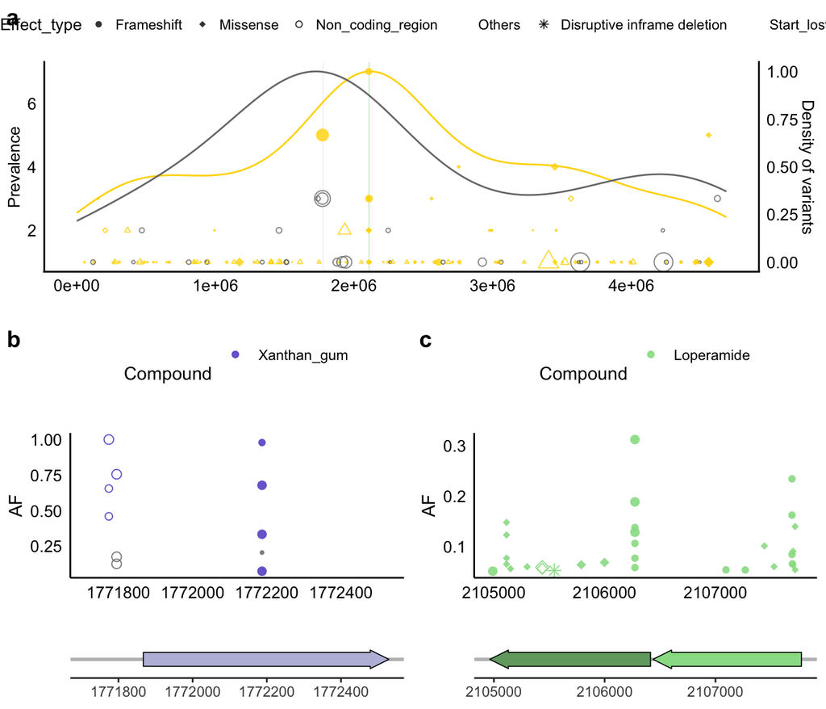